# tidymodels: Boilerplates

https://www.tidymodels.org/

# 1 xgboost template

## 1.1 library setup

```r
library(tidyverse)
ggplot2::theme_set(theme_light())
library(tidylog, warn.conflicts = FALSE) # load this last!

library(skimr)
library(patchwork)
library(gt)
library(janitor) # data cleaning

# install treesnip to allow catboost, lightGBM in parsnip binding
# remotes::install_github("curso-r/treesnip")

library(tidymodels)
# tidymodels
# library(rsample)
# library(recipes)
# library(parsnip)
# library(tune)
# library(dials)
# library(workflows)
# library(yardstick)

# speed up computation with parrallel processing (optional)
library(doParallel)
all_cores <- parallel::detectCores(logical = FALSE)
registerDoParallel(cores = all_cores)

# set the random seed so we can reproduce any simulated results.
set.seed(1234)
```

## 1.2 data setup

```r
# load the housing data and clean names
library(AmesHousing)
```

## 1.3 data cleanup

```r
ames_data <- make_ames() %>%
    janitor::clean_names()
```

# 2 Exploratory Data Analysis

At this point we would normally make a few simple plots and summaries of the data to get a high-level understanding of the data.

For simplicity, we are going to cut the EDA process here, but, in a real-world analysis, understanding the business problems and doing effective EDA are often the most time consuming and crucial aspects of the analysis.

# 3 Allocating training and testing datasets

Now we split the data into training and test data. Training data is used for the model training and hyperparameter tuning. Once trained, the model can be evaluated against test data to assess accuracy.

```r
# Stratify by Sale price
ames_split <- rsample::initial_split(
    ames_data,
    prop = 0.8,
    strata = sale_price
)
```

# 4 Pre-processing

Preprocessing alters the data to make our model more predictive and the training process less compute intensive. Many models require careful and extensive variable preprocessing to produce accurate predictions.

XGBoost, however, is robust against highly skewed and/or correlated data, so the amount of preprocessing required with XGBoost is minimal.

Nevertheless, we can still benefit from some preprocessing.

In tidymodels, we use the `recipes::` package to define these preprocessing steps, in what is called a *recipe*.

```r
preprocessing_recipe <-
    recipes::recipe(sale_price ~ ., data = training(ames_split)) %>%
    # convert categorical variables to factors
    recipes::step_string2factor(all_nominal()) %>%
    # combine low frequency factor levels
    recipes::step_other(all_nominal(), threshold = 0.01) %>%
    # remove no variance predictors which provide no predictive information
    recipes::step_nzv(all_nominal()) %>%
    prep()
```

# 5 Cross validate

```r
ames_cv_folds <-
    recipes::bake(
        preprocessing_recipe,
        new_data = training(ames_split)
    ) %>%
    rsample::vfold_cv(v = 5)
```

# 6 XGBoost model specification

```r
xgboost_model <-
    parsnip::boost_tree(
        mode = "regression",
        trees = 1000,
        min_n = tune(),
        tree_depth = tune(),
        learn_rate = tune(),
        loss_reduction = tune()
    ) %>%
    set_engine("xgboost", objective = "reg:squarederror")
```

# 7 Hyperparameter tuning

## 7.1 grid specification by dials

```r
# to fill in the model above
xgboost_params <-
    dials::parameters(
        min_n(),
        tree_depth(),
        learn_rate(),
        loss_reduction()
    )
```

and the grid to look in Experimental designs for computer experiments are used to construct parameter grids that try to cover the parameter space such that any portion of the space has an observed combination that is not too far from it.

```r
xgboost_grid <-
    dials::grid_max_entropy(
        xgboost_params,
        size = 20 # this started at 60, but even 30 is taking forever!
    )
```

To tune our model, we perform grid search over our xgboost_grid’s grid space to identify the hyperparameter values that have the lowest prediction error.

# 8 Workflow setup

```r
xgboost_wf <-
    workflows::workflow() %>%
    add_model(xgboost_model) %>%
    add_formula(sale_price ~ .)
```

So far little to no computation has been performed except for preprocessing calculations

# 9 Tune the Model

Tuning is where the tidymodels ecosystem of packages really comes together. Here is a quick breakdown of the objects passed to the first 4 arguments of our call to tune_grid() below:

- “object”: xgboost_wf which is a workflow that we defined by the parsnip and workflows packages
- “resamples”: ames_cv_folds as defined by rsample and recipes packages
- “grid”: xgboost_grid our grid space as defined by the dials package
- “metric”: the yardstick package defines the metric set used to evaluate model performance

## 9.1 hyperparameter tuning

This is where the machine starts to smoke!

```r
if(!file.exists("tuned/xgboost_tuned.rds")) {
system.time({
xgboost_tuned <- tune::tune_grid(
    object = xgboost_wf,
    resamples = ames_cv_folds,
    grid = xgboost_grid,
    metrics = yardstick::metric_set(rmse, rsq, mae),
    control = tune::control_grid(verbose = TRUE)
)
})
save(xgboost_tuned, file="xgboost_tuned.rds")
} else {
  load("tuned/xgboost_tuned.rds")
}
```

- Don’t try that on your notebook!

These are the hyperparameter values which performed best at minimizing RMSE.

```r
xgboost_tuned %>%
    tune::show_best(metric = "rmse")
```

```
-->  # A tibble: 5 x 10
-->    min_n tree_depth learn_rate loss_reduction .metric .estimator    mean     n std_err .config
-->    <int>      <int>      <dbl>          <dbl> <chr>   <chr>        <dbl> <int>   <dbl> <chr>
-->  1    19          4   0.0208         1.71e- 2 rmse    standard    23033.     5   1664. Preprocessor1_Model06
-->  2    12         14   0.00828        1.68e- 6 rmse    standard    23173.     5   1757. Preprocessor1_Model12
-->  3    38          5   0.0237         4.75e- 9 rmse    standard    23881.     5   1727. Preprocessor1_Model09
-->  4    34          1   0.0119         3.00e+ 1 rmse    standard    28648.     5   1629. Preprocessor1_Model01
-->  5    40         11   0.000213       6.57e-10 rmse    standard   161883.     5   1908. Preprocessor1_Model08
```

```r
# Next, isolate the best performing hyperparameter values.
xgboost_best_params <- xgboost_tuned %>%
    tune::select_best("rmse")
xgboost_best_params
```

```
-->  # A tibble: 1 x 5
-->    min_n tree_depth learn_rate loss_reduction .config
-->    <int>      <int>      <dbl>          <dbl> <chr>
-->  1    19          4     0.0208         0.0171 Preprocessor1_Model06
```

# 10 Finalize the XGBoost model to use the best tuning parameters.

```r
xgboost_model_final <- xgboost_model %>%
    finalize_model(xgboost_best_params)
```

# 11 Evaluate Performance on Test Data

We use the rmse (Root Mean Squared Error), rsq (R Squared), and mae (Mean Absolute Value) metrics from the yardstick package in our model evaluation.

## 11.1 Tranining data

First let’s evaluate the metrics on the training data

```r
train_processed <- bake(preprocessing_recipe,  new_data = training(ames_split))

train_prediction <- xgboost_model_final %>%
    # fit the model on all the training data
    fit(
        formula = sale_price ~ .,
        data    = train_processed
    ) %>%
    # predict the sale prices for the training data
    predict(new_data = train_processed) %>%
    bind_cols(training(ames_split))

xgboost_score_train <-
    train_prediction %>%
    yardstick::metrics(sale_price, .pred) %>%
    mutate(.estimate = format(round(.estimate, 2), big.mark = ","))
```

```
-->      ---->  mutate: converted '.estimate' from double to character (0 new NA)
```

```r
xgboost_score_train
```

```
-->  # A tibble: 3 x 3
-->    .metric .estimator .estimate
-->    <chr>   <chr>      <chr>
-->  1 rmse    standard   "11,999.57"
-->  2 rsq     standard   "     0.98"
-->  3 mae     standard   " 8,573.06"
```

## 11.2 Test data

And now for the test data:

```r
test_processed  <- bake(preprocessing_recipe,
                        new_data = testing(ames_split))

test_prediction <- xgboost_model_final %>%
    # fit the model on all the training data
    fit(
        formula = sale_price ~ .,
        data    = train_processed
    ) %>%
    # use the training model fit to predict the test data
    predict(new_data = test_processed) %>%
    bind_cols(testing(ames_split))
```

Measure the accuracy of our model using `yardstick`.

```r
xgboost_score <-
    test_prediction %>%
    yardstick::metrics(sale_price, .pred) %>%
    mutate(.estimate = format(round(.estimate, 2), big.mark = ","))
```

```
-->      ---->  mutate: converted '.estimate' from double to character (0 new NA)
```

```r
xgboost_score
```

```
-->  # A tibble: 3 x 3
-->    .metric .estimator .estimate
-->    <chr>   <chr>      <chr>
-->  1 rmse    standard   "29,657.76"
-->  2 rsq     standard   "     0.87"
-->  3 mae     standard   "15,296.45"
```

To quickly check that there is not an obvious issue with our model’s predictions, let’s plot the test data residuals.

```r
house_prediction_residual <- test_prediction %>%
    arrange(.pred) %>%
    mutate(residual_pct = (sale_price - .pred) / .pred) %>%
    select(.pred, residual_pct)
```

```
-->      ---->  mutate: new variable 'residual_pct' (double) with 584 unique values and 0% NA
-->      ---->  select: dropped 81 variables (ms_sub_class, ms_zoning, lot_frontage, lot_area, street, …)
```

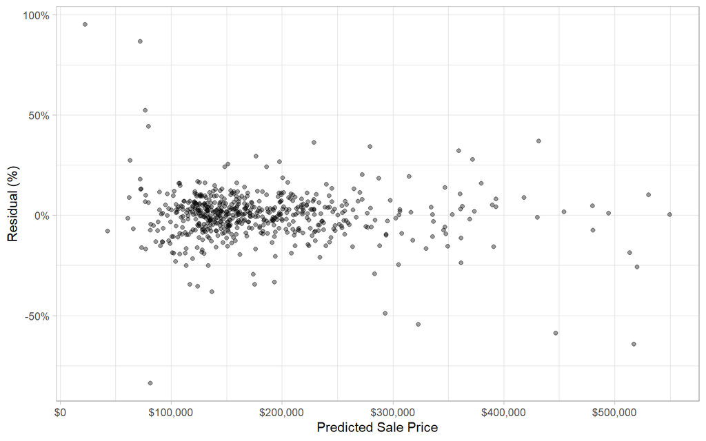

```r
ggplot(house_prediction_residual, aes(x = .pred, y = residual_pct)) +
    geom_point(alpha=0.4) +
    xlab("Predicted Sale Price") +
    ylab("Residual (%)") +
    scale_x_continuous(labels = scales::dollar_format()) +
    scale_y_continuous(labels = scales::percent)
```